# Homework Chapter 4

SOLUTIONS

## Instructions

This Homework comes from Chapter 4 of the Textbook. You should refer to AE_CH4 for some template code.

Complete the following exercises:

- E.1
- E.2
- E.3 (can take a picture of your by-hand drawing and embed as image in your .html, or use R to generate and plot dummy data that fits the criteria described).
- E.4
- Choose THREE of E.5 - E.11 to complete. Each uses a different data set you haven’t yet analyzed - choose the three that are most interesting to you.

```r
library(tidyverse)
library(janitor)
library(broom)
library(cowplot)
```

## E.1

Answers will vary. Possible solutions below.

#### Part a

> sales could be cylical and fluxate during different weeks of the year; location of the advertisement in the newspaper; appeal of the item(s) for which coupon is provided. These will all be controlled by holding them constant throughout the experiment. Random allocation will be used to control for other potential extraneous variables.

#### Part b

> Advertisement, 3 levels:
> - no advertisement
> - advertisement offering coupon for one free item
> - advertisement offering a coupon for a discount on multiple items

> Location, 4 levels (4 cities)

#### Part c

> Answers will vary. One option: percent increase in sales, since different stores may already have different levels of sales, and an increase in sales of the same amount at two stores may be different increases in total sales, which gives more information than an increase in sales alone.

#### Part d

> Answers will vary. If funds are available, could test each type of ad three times at each location. Thus, each of the four locations will have 9 weeks of advertisements, so that there are 36 observational units.

#### Part e

> Answers will vary. Order in which things will be tested should be randomized in some way. One solution: order will be randomly decided at each city; order of factor level combinations will be randomized since each factor-level combination could influence the results of the next factor-level combination.

#### Part f

> Ad factor will have 2 degrees of freedom, and location factor will have 3.

## E.2

#### Part a

> Answers will vary. Potential solution: location of the tomatoes in the garden could influence the results, as some areas may have more sunlight. The amount of water each tomato recieves could also influence the results; the group where the tomatoes are planted could also influence them. To control for these variables, the tomatoes would have to be planted randomly throughout the garden, the garden would have to be checked to make sure the soil is homogeneous, and each tomato would have to be watered the same amount.

#### Part b

> The units are the tomatoes, and a sample size of preferably thirty or greater so that there are five tomatoes tested at each factor level combination.

#### Part c

> The six factor-level combinations are fertilizer and no fertilizer for each species of tomato (3). The order in which each plant is assigned to a fertilizer will be randomized; the species of tomato cannot be randomized. However, each spot in the garden can be randomly assigned a species of tomato and whether fertilizer is added.

#### Part d

> The fertilizer factor has 1 df, and species of tomato has 2 df

## E.3

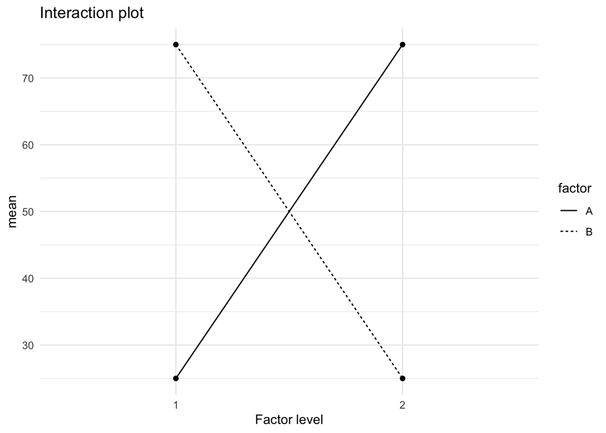

```r
data <- data.frame(factor = c("A", "A",
                              "B", "B"),
                   level = c(1, 2, 1, 2),
                   mean = c(25, 75, 75, 25))

ggplot(data, aes(x = factor(level), y = mean,
                 group = factor,
                 linetype = factor)) +
  geom_point() +
  geom_line() +
  labs(title = "Interaction plot",
       x = "Factor level") +
  theme_minimal()
```

## E.4

#### Part a

$$y_{ijkl} = \mu + \alpha_i + \beta_j + \gamma_k + (\alpha\beta)_{ij} + (\alpha\gamma)_{ik} + (\beta\gamma)_{jk} + \epsilon_{ijkl},$$

where $i = 1,2; \ \ j = 1,2; \ \ k = 1,2; \ \ l = 1,2,3,4$

#### Part b

$$SSC = \sum_{k = 1}^K n_{k}(\overline{y}_{\cdot\cdot k \cdot} - \overline{y}_{\cdot\cdot \cdot \cdot})^2$$

$$SSBC = \sum_{j = 1}^J\sum_{k = 1}^K n_{jk}(\overline{y}_{\cdot j k \cdot} -\overline{y}_{\cdot j \cdot \cdot} - \overline{y}_{\cdot\cdot k \cdot} + \overline{y}_{\cdot\cdot \cdot \cdot})^2$$

$$MSC = \frac{SSC}{df_C}$$
$$MSBC = \frac{SSBC}{df_{BC}}$$

$$F_{C} = \frac{MSC}{MSE}$$

$$F_{BC} = \frac{MSBC}{MSE}$$

#### Part c

Compute main effects:

```r
popcorn <- read_csv("./data/C4 Popcorn.csv") %>%
  clean_names()

compute_main_effect <- function(data,
                                explanatory_variable,
                                response_variable){
  grand_mean <- data %>%
    summarize(mean(!!sym(response_variable))) %>%
    pull()
  data %>%
    #!!sym() is just the syntax used to pass a string
    #to a variable name to be used in a tidyverse fxn
    group_by(!!sym(explanatory_variable)) %>%
    summarize(group_mean = mean(!!sym(response_variable))) %>%
    mutate(main_effect = group_mean - grand_mean)

}
brand_ME <- compute_main_effect(popcorn,
                                "brand", "pop_rate")
microwave_ME <- compute_main_effect(popcorn,
                                "microwave", "pop_rate")
time_ME <- compute_main_effect(popcorn,
                                "time", "pop_rate")

brand_ME
```

| brand | group_mean | main_effect |
| --- | --- | --- |
| Fastco | 81.75507 | 0.4114031 |
| Pop Secret | 80.93226 | -0.4114031 |

```r
microwave_ME
```

| microwave | group_mean | main_effect |
| --- | --- | --- |
| Lounge | 80.42122 | -0.9224406 |
| Room | 82.26611 | 0.9224406 |

```r
time_ME
```

| time | group_mean | main_effect |
| --- | --- | --- |
| 105 | 78.28701 | -3.056659 |
| 135 | 84.40032 | 3.056659 |

Create main effects plots:

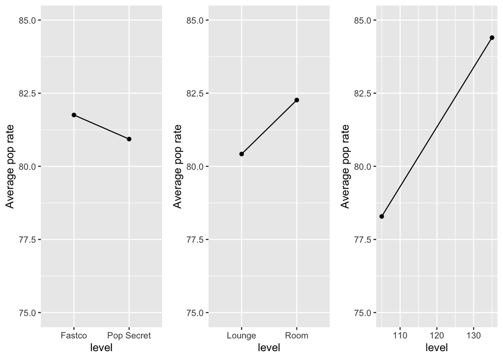

```r
main_effects_plot <- function(data,
                              explanatory_variable,
                              response_variable,
                              ylimits,
                              labels){
  data %>%
    #!!sym() is just the syntax used to pass a string
    #to a variable name to be used in a tidyverse fxn
    group_by(!!sym(explanatory_variable)) %>%
    summarize(mean = mean(!!sym(response_variable))) %>%
    ggplot(aes(y = mean, x = !!sym(explanatory_variable),
             group = 1)) +
    geom_point() +
    geom_line() +
    ylim(ylimits[1], ylimits[2]) +
    labs(x = labels[1],
         y = labels[2])
}
#create main effects plot for microwave factor
#(and save as object p1)
p1 <- main_effects_plot(popcorn, "brand", "pop_rate",
                  c(75, 85),
                  c("level", "Average pop rate"))
p2 <- main_effects_plot(popcorn, "microwave", "pop_rate",
                  c(75, 85),
                  c("level", "Average pop rate"))
p3 <- main_effects_plot(popcorn, "time", "pop_rate",
                  c(75, 85),
                  c("level", "Average pop rate"))
plot_grid(p1, p2, p3, nrow = 1)
```

> The graph helps us to visualize the effect size since the y-axis is hte same across all the graphs, so we can visually compare the difference in the effect size across all the factors. We quickly see that the effect of time is larger than the other factors.

#### Part d

```r
colnames(brand_ME) <- c("brand", "group_mean_i", "main_effect_i")
colnames(microwave_ME) <- c("microwave", "group_mean_j", "main_effect_j")
IE <- popcorn %>%
  group_by(brand, microwave) %>%
  summarize(group_mean_ij = mean(pop_rate),
            n = n()) %>%
  ungroup() %>%
  left_join(brand_ME) %>%
  left_join(microwave_ME) %>%
  mutate(grand_mean = weighted.mean(group_mean_ij, n),
         IE = group_mean_ij  -
           (main_effect_i + main_effect_j +
              grand_mean)) %>%
  relocate(IE)
IE
```

| IE | brand | microwave | group_mean_ij | n | group_mean_i | main_effect_i | group_mean_j | main_effect_j | grand_mean |
| --- | --- | --- | --- | --- | --- | --- | --- | --- | --- |
| 0.7951719 | Fastco | Lounge | 81.62780 | 8 | 81.75507 | 0.4114031 | 80.42122 | -0.9224406 | 81.34367 |
| -0.7951719 | Fastco | Room | 81.88234 | 8 | 81.75507 | 0.4114031 | 82.26611 | 0.9224406 | 81.34367 |
| -0.7951719 | Pop Secret | Lounge | 79.21465 | 8 | 80.93226 | -0.4114031 | 80.42122 | -0.9224406 | 81.34367 |
| 0.7951719 | Pop Secret | Room | 82.64987 | 8 | 80.93226 | -0.4114031 | 82.26611 | 0.9224406 | 81.34367 |

> The interaction effect of Room*Fastco is calculated as

$$\begin{aligned}
&= \text{average of Room, Fastco group - (effect of Room + effect of Fastco + grand mean)} \\
&= \overline{y}_{12\cdot} - [\hat{\alpha}_1 + \hat{\beta}_2 + \overline{y}_{\cdot \cdot \cdot}] \\
&= 81.882 - [0.411 + 0.922 + 81.344] \\
&= -0.795
\end{aligned}$$

## Reflection prompts

*Respond to each of the following after you have completed all exercises in this assignment*

*(RP1): What were the main concepts covered in this assignment?*

*(RP2): What’s one thing you understand better after completing these exercises?*

*(RP3): What exercise(s) gave you the most trouble? What was difficult about them/where did you get stuck?*